# BMSS R Tutorial 4: Intro to stats- ANOVA and regression

Justin Baumann

26 August, 2021

# **LEARNING OBJECTIVES**

IN THIS TUTORIAL YOU WILL LEARN:  
1.) The theory behind a T-test and how to perform one 2.) The theory behind analysis of variance and how to perform it 3.) How to test model/ statistical assumptions (and why) 4.) How to perform a linear regression

# Additional Tutorials and Resources for basic statistics in R

t-tests

[More advanced info on t-tests](http://www.sthda.com/english/wiki/unpaired-two-samples-t-test-in-r)

[one-way ANOVA](http://www.sthda.com/english/wiki/one-way-anova-test-in-r)

[Advanced ANOVA](https://www.datanovia.com/en/lessons/anova-in-r/)

[For the bold: Linear Models (an intro)](https://ourcodingclub.github.io/tutorials/modelling/)

[For the bold part II: Mixed effects models](https://ourcodingclub.github.io/tutorials/mixed-models/)

# **1.) Load packages we need**

Here we are loading our usual packages plus some additional ones for statistics. Performance is very useful as an assumption checker, so we will rely heavily on it. I’ll also show you how to assess outliers using rstatix.

```r
library(tidyverse) #For data manipulation and graphing
library(ggsci) #for color scales
library(patchwork)  #to panel our graphs
library(performance) #check stat/model assumptions
library(see)
library(rstatix) #test for outliers
```

# **2.) A note on statistics and experimental design**

Statistics is a complex field with a long history. We could spend an entire course or even an entire career focusing on the intricate details of statistical decisions and ideas. However, that is not the focus of BMSS! Instead, we want you to have the statistical grounding necessary to plan your experiments and analyze your data. For biologists, statistics are a tool we can leverage to perform the best possible experiments and test our hypotheses.

You are ideally going to design an independent research project. That project will likely be driven by an overarching question or hypothesis. At the end of the project, we want you to the right kind of data (and enough data) to assess whether your hypothesis was true or not! That is why experimental design and statistics go hand in hand. This tutorial dives somewhat deeply into sampling design. This may seem boring and unnecessary but if you are able to think about your own experiment in these terms you will make sure you have enough replication to actually assess your hypothesis!

# **3.) The T-test**

## **T-test theory**

The t-test (or students’ t-test) is a basic statistical test used to assess whether or not the means of two groups are different from one another. In this test, the null hypothesis is that the two means are equal (or that there is no difference between the two means).

A t-test should only be used if the following assumptions are met: **1.)** the two distributions whose means we are comparing must be **normally distributed** **2.)** The variances of the two groups must be **equal**

**Assessing normality** Method 1: the Shaprio-Wilk Test. If p < 0.05 then the distribution is signficantly different from normal.

```r
shapiro.test(mtcars$mpg) #this is normally distributed
```

```
##
##  Shapiro-Wilk normality test
##
## data:  mtcars$mpg
## W = 0.94756, p-value = 0.1229
```

```r
shapiro.test(mtcars$cyl) # this is not
```

```
##
##  Shapiro-Wilk normality test
##
## data:  mtcars$cyl
## W = 0.75331, p-value = 6.058e-06
```

```r
shapiro.test(mtcars$hp) #this is not normal (but very close to p=0.05)
```

```
##
##  Shapiro-Wilk normality test
##
## data:  mtcars$hp
## W = 0.93342, p-value = 0.04881
```

```r
shapiro.test(mtcars$wt) #this is normal
```

```
##
##  Shapiro-Wilk normality test
##
## data:  mtcars$wt
## W = 0.94326, p-value = 0.09265
```

Method 2: Visualization

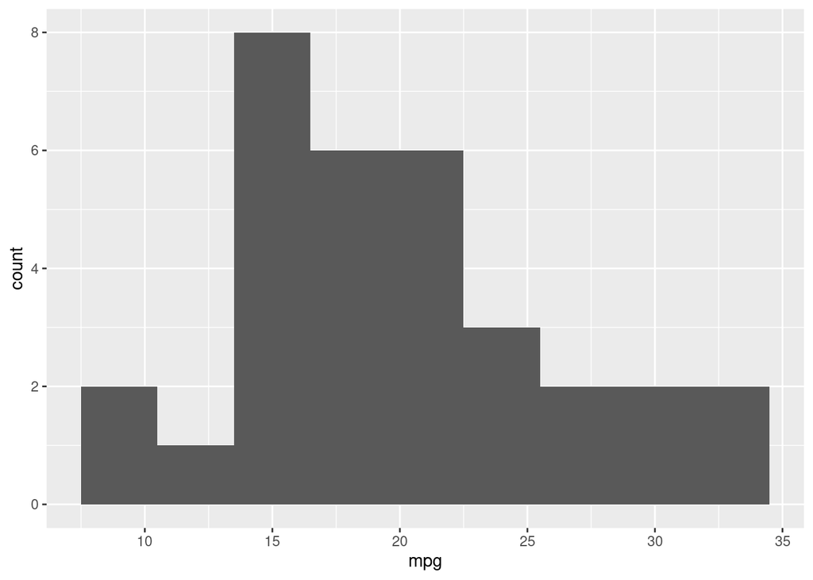

```r
ggplot(data=mtcars, aes(mpg))+
  geom_histogram(binwidth = 3) #looks normal
```

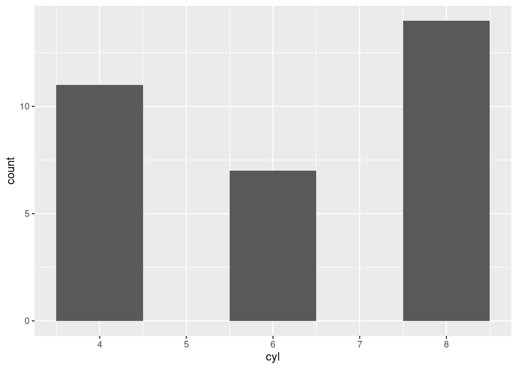

```r
ggplot(data=mtcars, aes(cyl))+
  geom_histogram(binwidth=1) #NOT normal
```

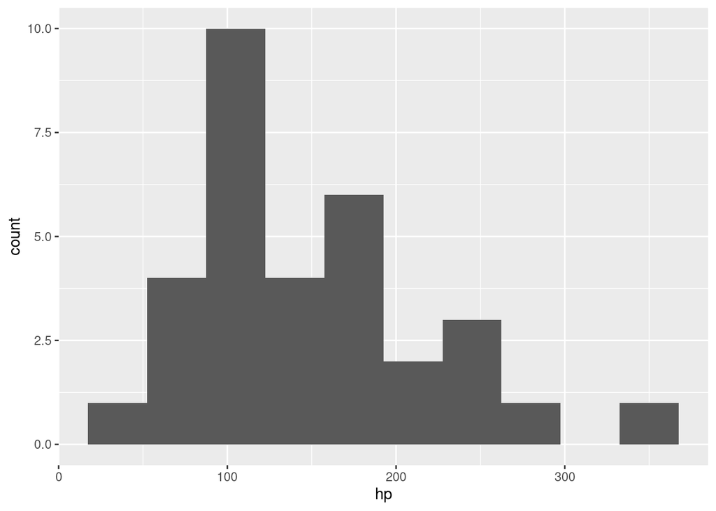

```r
ggplot(data=mtcars, aes(hp))+
  geom_histogram(binwidth=35) #looks near normal, with some skew
```

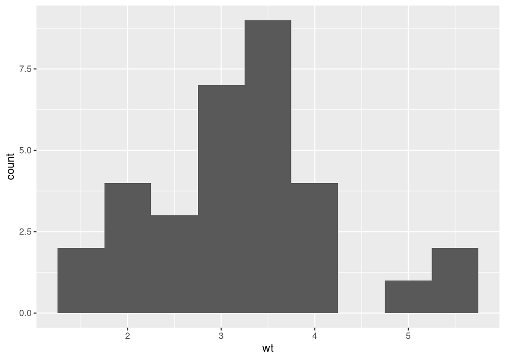

```r
ggplot(data=mtcars, aes(wt))+
  geom_histogram(binwidth=0.5) #looks normal
```

**Can we ignore either of these 2 assumptions?**

We can if our sample sizes are large. If n is small, we should not ignore this assumption. There are alternatives to dealing with normality that we can discuss in the ANOVA section (such as transforming the data)

[For more info on that](https://thestatsgeek.com/2013/09/28/the-t-test-and-robustness-to-non-normality/)

We can also ignore the equal variance requirement if we use the Welch t-test (default in R)

## **A basic T-test in R**

Let’s compare two columns in the mtcars data frame

Do the means of mpg and cyl differ?

```r
t.test(mtcars$mpg,mtcars$cyl, alternative='two.sided', var.equal=FALSE) #two.sided and var.equal= FALSE are default, so we don't have to list them. BUt, we can also change them (as I will show later)
```

```
##
##  Welch Two Sample t-test
##
## data:  mtcars$mpg and mtcars$cyl
## t = 12.512, df = 36.402, p-value = 9.508e-15
## alternative hypothesis: true difference in means is not equal to 0
## 95 percent confidence interval:
##  11.65034 16.15591
## sample estimates:
## mean of x mean of y
##  20.09062   6.18750
```

The result of the above t.test shows that p<0.05, so these two means are different. Now, which one is lower? Through looking at the plots we obviosuly know it is cyl, but we can confirm that with a t.test if we want!

**Is the mean of mpg > cyl?**

```r
t.test(mtcars$mpg,mtcars$cyl, alternative='greater', var.equal=FALSE) #'greater' here technically asks if the diffrence in means is > zero (in which case, the variable listed first would have a mean higher than the variable listed second)
```

```
##
##  Welch Two Sample t-test
##
## data:  mtcars$mpg and mtcars$cyl
## t = 12.512, df = 36.402, p-value = 4.754e-15
## alternative hypothesis: true difference in means is greater than 0
## 95 percent confidence interval:
##  12.02761      Inf
## sample estimates:
## mean of x mean of y
##  20.09062   6.18750
```

```r
t.test(mtcars$mpg,mtcars$cyl, alternative='less', var.equal=FALSE) #'less' here technically asks if the diffrence in means is < zero (in which case, the variable listed first would have a mean lower than the variable listed second)
```

```
##
##  Welch Two Sample t-test
##
## data:  mtcars$mpg and mtcars$cyl
## t = 12.512, df = 36.402, p-value = 1
## alternative hypothesis: true difference in means is less than 0
## 95 percent confidence interval:
##      -Inf 15.77864
## sample estimates:
## mean of x mean of y
##  20.09062   6.18750
```

As you can see, we can use a t-test to tell us if there is a difference in means between the two groups we are looking at. Which is fine, but not always very useful. Our example here was totally frivolous. We don’t need statistics to tell us that the mean of cylinder (which is between 4 and 8) and the mean of mpg (which ranges between <10 and >20) are obviously different. We would already expect that.

SO, when is a t-test actually useful and when isn’t it? Most of the time, this is not the most useful test. That is why we need ANOVA!

# **4.) Analysis of Variance (ANOVA)**

## **ANOVA theory**

Analysis of variance (ANOVA) is a common statistical test used to compare the means of multiple groups. A t-test can only compare the means of 2 groups. ANOVA can compare many groups, making it much more likely to be useful.

Let’s take a look at the theory behind ANOVA.

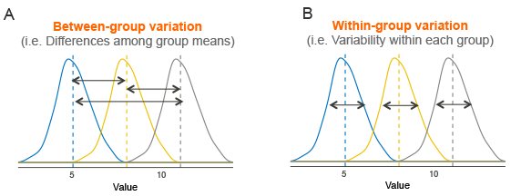

ANOVA theory - datanovia.com

This figure has 3 groups (blue, yellow, and gray) with means represented by dotted vertical lines. The solid lines are the distributions of each group (essentially, the variation with-in a group). This variation within a group is called **residual variance** (Panel B). The goal ANOVA is to compare means to see if they differ. The way ANOVA works is that it compares the variance between groups (Panel A) with the residual variance (Panel B). If between group variance is great enough when compared to residual variance then you can conclude that there is some kind of difference between group means (at least 1 group mean differs from the others).

In summary: An ANOVA is a comparison of 2 variance estimates (between group vs within group), that is why we call is analysis of variance even though it really assess differences between means.

ANOVA relies on something called the **F-statistic** which we can calculate as: variance between groups / variance within groups (residual variance)

## **Assumption of ANOVA**

ANOVA operates best under the following assumptions:

**1.) Independence of observations** (each subject belongs to only 1 group, every observation is independent of other observations. There is no relationship or correlation between the observations in each group.)

**2.) No significant outliers exist**

**3.) Normality:** The data are approximately normally distributed

**4.) Homogeneity of variances** (the variance of the outcome variable should be similar in all groups)

NOTE on assumption violations:

Independence is the single most important assumption. It should not be violated. If it is, best practice is to run a different (non-parametric) statistical test.

The outlier assumption is easily handled, as outliers can be removed from data. That said, modern best practices in statistics encourage the user to remove fewer outliers (and only remove extreme outliers). This assumption is often ignored at little cost.

As with t-tests, if sample sizes are large enough (which they almost always are), the normality assumption can be violated. With small sample sizes you can transform your data to make it normal (w/ log, natural log, or square root).

Homogeneity of variances (Homoscedasticity). This one is complicated. In short,as long as sample sizes (n) are the same (or similar) for your groups, even with low sample sizes you can usually violate this assumption and be fine. Most people DO NOT even test for this assumption (or any of the others), but… it seems possible that any p-values derived from any ANOVA in which assumptions are violated are not that trustworthy.

There is a lot of argument about how and what the best practices for ANOVA are. Truthfully, I do not fully understand all of this, but I will show you how to do a few tests on your data before doing an ANOVA, just to be careful. I will argue for better statistical practices (that move beyond ANOVA and p-values in general) next week (if we have time).

## **Testing assumptions**

**1.) Independence.** We need to consider our experimental design to test this one.

**2.) Outliers** To look for outliers, we can use a boxplot. Or the identify_outliers() function in the rstatix package. Here, we see outliers in the 8 cylinder group, but they are not extreme and are likely only outliers due to low n. So we will keep them (this is a judgment call)

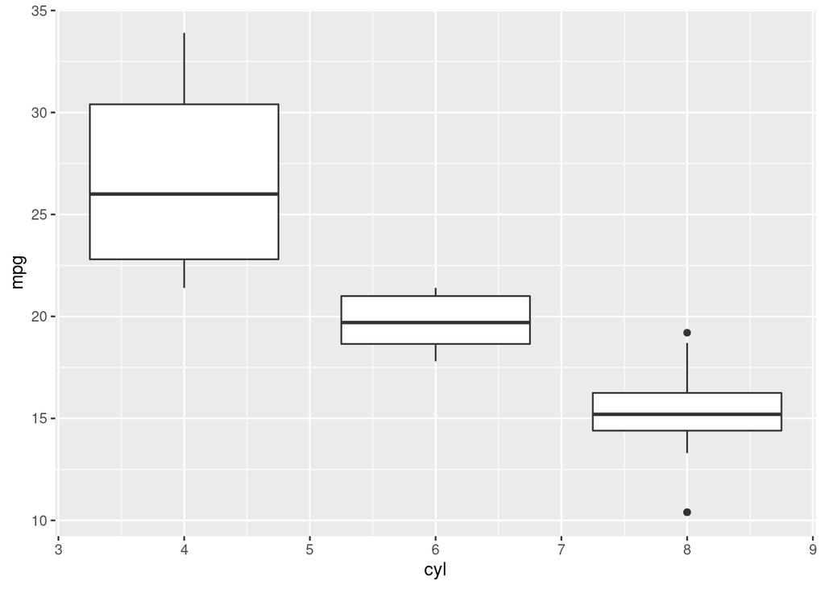

```r
ggplot(data=mtcars, aes(x=cyl, y=mpg, group=cyl))+
  geom_boxplot() #dots are outliers, we see 2 in the 8 cyl group. But do they really look like outliers???
```

```r
#make cyl a factor! This matters :)
mtcars$cyl=as.factor(mtcars$cyl)


#identifying outliers using the rstatix package!
mtcars %>%
  group_by(cyl) %>%
  identify_outliers(mpg) #Here we can see that the 2 points we saw in the boxplot are actually 3 (2 of the outliers have the same mpg). They test as outliers but NOT extreme outliers. So we will not remove them.
```

| cyl | mpg | disp | hp | drat | wt | qsec | vs | am | gear | carb | is.outlier | is.extreme |
| --- | --- | --- | --- | --- | --- | --- | --- | --- | --- | --- | --- | --- |
| 8 | 10.4 | 472 | 205 | 2.93 | 5.250 | 17.98 | 0 | 0 | 3 | 4 | TRUE | FALSE |
| 8 | 10.4 | 460 | 215 | 3.00 | 5.424 | 17.82 | 0 | 0 | 3 | 4 | TRUE | FALSE |
| 8 | 19.2 | 400 | 175 | 3.08 | 3.845 | 17.05 | 0 | 0 | 3 | 2 | TRUE | FALSE |

**3. & 4.) Normality and Homoscedasticity**

We can test normality and homoscedasticity of the entire anova using check_model() in the Performance package.

```r
model1<-aov(mpg~cyl, data=mtcars) #this is our ANOVA model! We will learn more about this on the next tab
check_model(model1)
```

```
## Not enough model terms in the conditional part of the model to check for multicollinearity.
```

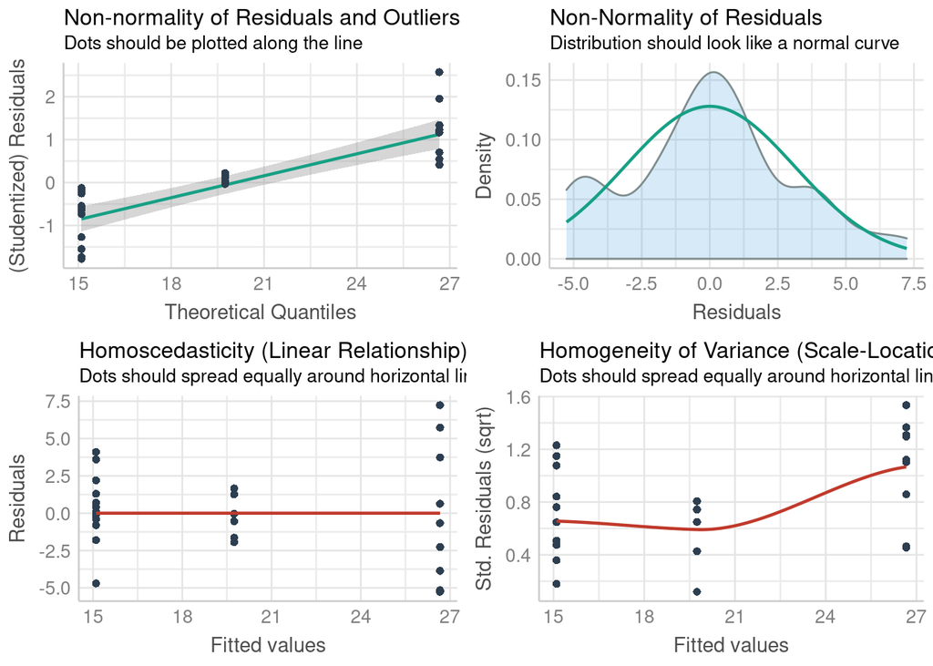

We can also assess normality using a Shapiro-Wilk test. If p<0.05 then normality CANNOT be assumed.

```r
shapiro_test(residuals(model1)) #here, we have a normal (nearly) distribution
```

| variable | statistic | p.value |
| --- | --- | --- |
| residuals(model1) | 0.9706547 | 0.517665 |

To assess normality by group we must use the pipe %>% again!Here, we see that we have normal dist for all 3 groups

```r
mtcars %>%
  group_by(cyl) %>%
  shapiro_test(mpg) #from the rstatix package. Note: the base R version shapiro.test doesn't work here
```

| cyl | variable | statistic | p |
| --- | --- | --- | --- |
| 4 | mpg | 0.9124392 | 0.2605931 |
| 6 | mpg | 0.8990350 | 0.3251776 |
| 8 | mpg | 0.9317532 | 0.3228563 |

To assess homogeneity of variance, we can use check_model to see it graphically. If we want to see numbers, we can use a levene test. A levene test p<0.05 indicates that there IS a significant difference in variances between the treatment groups. Compare this w/ our plots from check_model(). What do you think?

```r
mtcars %>%
  levene_test(mpg~cyl)
```

| df1 | df2 | statistic | p |
| --- | --- | --- | --- |
| 2 | 29 | 5.507065 | 0.0093902 |

Technically, the levene test tells us we cannot do an ANOVA without doing a welch test (which accounts for the different variances). So, we can do the welch test one-way anova. Looking at the data in our check_model, we can see pretty clearly that there is a difference in variance among out 3 cylinder groups. So that could be a problem. We can ignore this assumption due to high n (which is done often but isn’t always best practice), or we could do a modified version of the ANOVA that accounts for this difference in variation. This is called a welch test.

## **One-way Anova**

The simplest ANOVA is a one-way ANOVA, which is just an extension of a t-test. T-tests can only compare 2 means, but ANOVA can compare more than 2 groups. The simplest example of an ANOVA is when we have data organized by one grouping variable (hence, one-way). For example, if we want to know how mpg varies by cyl in mtcars, we would use a one-way anova. NOTE: if variance differs significantly between our groups, we want to run a welch_anova_test() instead of a one way anove (aov). welch_anova_test() is available in the rstatix package that we loaded above. aov() is present in base R.

So, let’s plot the data and then do some stats!

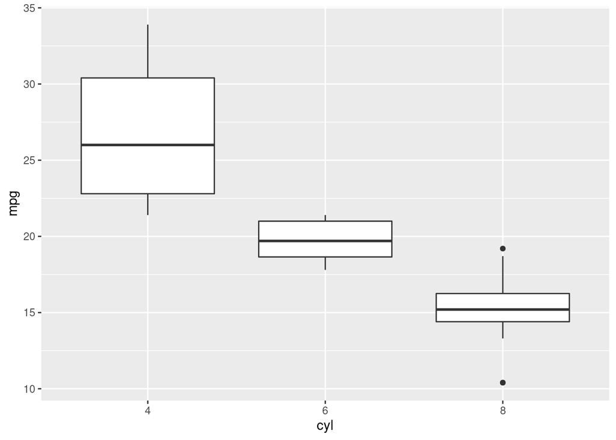

```r
ggplot(data=mtcars, aes(x=cyl, y=mpg, group=cyl))+
  geom_boxplot() #dots are outliers, we see 2 in the 8 cyl group. But do they really look like outliers???
```

```r
mtaov<-aov(mpg~cyl, data=mtcars)
mtaov #normally, an aov() will give us a p-value. Here it recognizes that "estimated effects may be unbalanced". We can find the p-value in summary()
```

```
## Call:
##    aov(formula = mpg ~ cyl, data = mtcars)
##
## Terms:
##                      cyl Residuals
## Sum of Squares  824.7846  301.2626
## Deg. of Freedom        2        29
##
## Residual standard error: 3.223099
## Estimated effects may be unbalanced
```

```r
summary(mtaov) #this anova will still give us a p-value
```

```
##             Df Sum Sq Mean Sq F value   Pr(>F)
## cyl          2  824.8   412.4    39.7 4.98e-09 ***
## Residuals   29  301.3    10.4
## ---
## Signif. codes:  0 '***' 0.001 '**' 0.01 '*' 0.05 '.' 0.1 ' ' 1
```

```r
welch_anova_test(mpg~cyl, data=mtcars) #here, we do get a p-value that is <0.05, suggesting that there is an effect of cylinders onf mpg
```

| .y. | n | statistic | DFn | DFd | p | method |
| --- | --- | --- | --- | --- | --- | --- |
| mpg | 32 | 31.62 | 2 | 18.03185 | 1.3e-06 | Welch ANOVA |

**A second example** Let’s apply those ANOVA skills to a new dataset. We will use the dataset called ‘iris’ that is built into R. It’s a simply dataframe that contains attributes of different flowers. It is similar to penguins!

First step: Let’s plot some data! I want to assess the effect of species on petal.length

```r
head(iris)
```

| Sepal.Length | Sepal.Width | Petal.Length | Petal.Width | Species |
| --- | --- | --- | --- | --- |
| 5.1 | 3.5 | 1.4 | 0.2 | setosa |
| 4.9 | 3.0 | 1.4 | 0.2 | setosa |
| 4.7 | 3.2 | 1.3 | 0.2 | setosa |
| 4.6 | 3.1 | 1.5 | 0.2 | setosa |
| 5.0 | 3.6 | 1.4 | 0.2 | setosa |
| 5.4 | 3.9 | 1.7 | 0.4 | setosa |

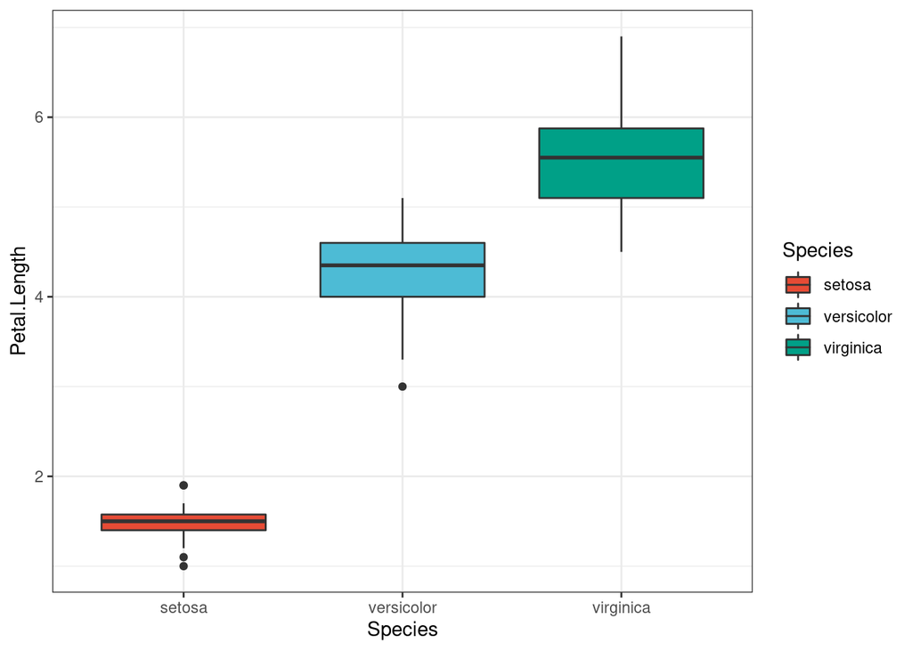

```r
ggplot(data=iris, aes(x=Species, y=Petal.Length, group=Species))+
  geom_boxplot(aes(fill=Species))+
  theme_bw()+ #remember this?
  scale_color_npg()+
  scale_fill_npg()
```

Our plot shows us that there is almost certainly an effect of species on petal length. But, let’s check that with an anova.